# BUA 455 Week 12 - Geo Data, Project Mgmt., R Publishing

Penelope Pooler Eisenbies

2023-11-14

```r
# this line specifies options for default options for all R Chunks
knitr::opts_chunk$set(echo=T,
                      highlight=T)

# suppress scientific notation
options(scipen=100,
        getSymbols.warning4.0 = FALSE)

# install helper package (pacman), if needed
if (!require("pacman")) install.packages("pacman", repos = "http://lib.stat.cmu.edu/R/CRAN/")
```

```r
# install and load required packages
# pacman should be first package in parentheses and then list others
pacman::p_load(pacman,tidyverse, ggthemes, magrittr, knitr, lubridate, gridExtra, RColorBrewer,
               flexdashboard, maps, usdata, countrycode, mapproj, shadowtext, grid)

# verify packages (comment out in finished documents)
p_loaded()
```

```
##  [1] "shadowtext"    "mapproj"       "countrycode"   "usdata"
##  [5] "maps"          "flexdashboard" "RColorBrewer"  "gridExtra"
##  [9] "knitr"         "magrittr"      "ggthemes"      "lubridate"
## [13] "forcats"       "stringr"       "dplyr"         "purrr"
## [17] "readr"         "tidyr"         "tibble"        "ggplot2"
## [21] "tidyverse"     "pacman"
```

### Housekeeping

- Final Proposals and Group Projects
  - Your participation in the final proposal and plan will affect your final grade on the project.
  - Group members that don’t contribute will not get credit for the work done by others in the group.
  - If you have data management questions, reach out to myself or a course TA.
  - We are here to help with tasks where you might be stymied, but don’t wait until the last day.
- Presentations will be on 12/12.
  - All students are required to attend and provide feedback.
- HW 5 - Part 2 will be posted over break but you can start it after break.
  - It will be due on 12/6
  - There is a 2 day grace period, if needed.
- Quiz 2 grading will be done over break because there are still a couple make-ups.

### Plans for today

- Two lectures on Geographic Data have been streamlined so that students also have time for group work this week.
- I will not cover them all in detail
- Rather than deleting notes and code that might be useful to some students all notes are provided.

#### Topics Covered

- Geographic Data: world data, state data, and filtering map data to a region
- Publishing work: More tips for good project management
  - Posting HTML files for free using **[Rpubs](https://rpubs.com/)**
    - Note: **[Rpubs](https://rpubs.com/)** is the best option for presenting and submitting your dashboard
- After break there will be more time to work in calss as well

### Importing and Joining World Datasets

#### World Data

```r
world <- map_data("world") |> select(!subregion)                              # world geo info
intbxo <- read_csv("intl_bxo.csv", show_col_types = F, skip=7) |>             # import/tidy bxo
  select(1,6) |>
  rename("region" = "Area", "wknd_gross" = "Weekend Gross") |>
  filter(!is.na(wknd_gross)) |>
  mutate(wknd_gross = gsub("$", "", wknd_gross, fixed = T),
         wknd_gross = gsub(",", "", wknd_gross, fixed = T) |> as.numeric())
world_bxo_data <- left_join(intbxo, world) |>                                # join datasets
  filter(!is.na(wknd_gross))
world_bxo_data$continent = countrycode(sourcevar = world_bxo_data$region,    # retrieve continents
                                       origin = "country.name",
                                       destination = "continent")
head(world_bxo_data, 3)
```

```
## # A tibble: 3 × 7
##   region wknd_gross  long   lat group order continent
##   <chr>       <dbl> <dbl> <dbl> <dbl> <int> <chr>
## 1 China    11661657  111.  20.0   418 28698 Asia
## 2 China    11661657  111.  19.9   418 28699 Asia
## 3 China    11661657  111.  19.9   418 28700 Asia
```

### Choropleth Country Plot w/ Labels

#### Example - Asia

- **Most** of the plot code that follows is review
  - There are a few new details:
    - `shadowtext` labels (see below)
    - modifying size of text elements (mentioned but not emphasized)
- **NOTES:**
  - The R package `shadowtext` includes the command `geom_shadowtext`
  - `shadowtext` is useful for creating visible labels for all countries regardless of color
  - Deciding on units ($1000) and transformation (`log`) took some trial and error.

### Managing Data for Asia Chropleth Map

#### This R code creates the Asia Map dataset

```r
asia_bxo_data <- world_bxo_data |>           # create asia box office dataset
  filter(continent=="Asia") |>
  mutate(Gross = as.integer(wknd_gross),
         wknd_gross = wknd_gross/1000)

asia_nms <- asia_bxo_data |>                         # create dataset of country names
  select(region, long, lat, group, continent) |>     # median lat and long used for position
  group_by(continent, region) |>
  summarize(nm_x=median(long, na.rm=T),
            nm_y=median(lat, na.rm=T)) |>
  filter(!is.na(nm_x) | !is.na(nm_y))
asia_bxo_data <- inner_join(asia_bxo_data, asia_nms) # merge datasets using an inner_join
```

### R code for Asia Static Map with Log Transformation

```r
asia_bxo_map <- asia_bxo_data |>    # Creates the map that follows
   ggplot(aes(x=long, y=lat, group=group, fill=wknd_gross)) +
   geom_polygon() +
   theme_map() +
   coord_map("albers", lat0 = 39, lat1 = 45) +
   labs(fill= "Gross ($1K)",
        title="Weekend Gross ($ Thousands) in Asian Countries",
        subtitle="Weekend Ending 11/12/2023 - Data are Log-transformed",
        caption="Data Source: https://www.boxofficemojo.com") +

   scale_fill_continuous(type = "viridis",  trans="log",
                         breaks =c(1,10,100,1000,10000)) +
   geom_shadowtext(aes(x=nm_x, y=nm_y,label=region),
                   color="white",check_overlap = T,
                   show.legend = F, size=4) +

   theme(plot.title = element_text(size = 20),
         plot.subtitle = element_text(size = 15),
         plot.caption = element_text(size = 10),
         legend.text = element_text(size = 12),
         legend.title = element_text(size = 15),
         plot.background = element_rect(colour = "darkgrey", fill=NA, size=2)) # adds a boarder
```

### Asia Static Map with Log (LN) Transformation

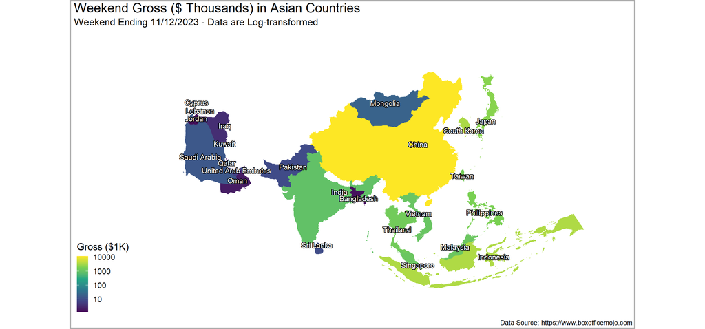

### Europe Map Data

Creates data for Europe Map

```r
euro_bxo_data <- world_bxo_data |>           # create Europe box office dataset
  filter(continent=="Europe" & region != "Russia") |>
  mutate(Gross = as.integer(wknd_gross),
         wknd_gross = wknd_gross/1000)

euro_nms <- euro_bxo_data |>                         # create dataset of country names
  select(region, long, lat, group, continent) |>     # median lat and long used for position
  group_by(continent, region) |>
  summarize(nm_x=median(long, na.rm=T),
            nm_y=median(lat, na.rm=T)) |>
  filter(!is.na(nm_x) | !is.na(nm_y))
euro_bxo_data <- inner_join(euro_bxo_data, euro_nms) # merge datasets using an inner_join
```

### Europe Static Map with Log (LN) Transformation

Student will create this map or interactive one by adapting Asia Map code

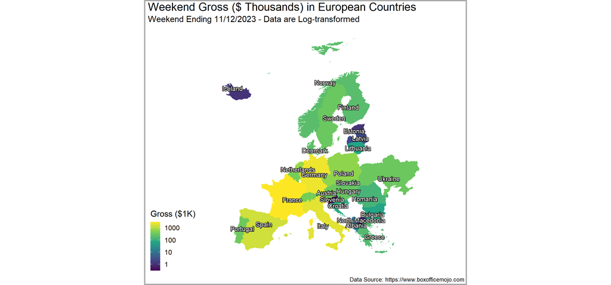

### US State data Example

- Examples of Data that can be plotted by state
  - Average costs and expenditures by state of specific goods or services
  - Demographic data
  - Voting and tex information
  - Sports/Arts/Entertainment/Education investments and expenditures
- Will also show a map of data filtered by region

### US State Map Data

```r
us_states <- map_data("state") |>          # state polygons (from R)
  select(long:region) |>
  rename("state" = "region")

state_abbr <- state_stats |>               # many useful variables in this dataset
  select(state, abbr) |>
  mutate(state = tolower(state))

state_pop <- county_2019 |>               # data by county (aggregated by state)
  select(state, pop) |>
  mutate(state=tolower(state),
         popM = pop/1000000) |>
  group_by(state) |>
  summarize(st_popM = sum(popM, na.rm=T)) |>
  full_join(state_abbr)
statepop_map <- left_join(us_states, state_pop) # used left join to filter to lower 48 states
                                                # lat/long not available for Hi and AK
```

### Adding State Midpoint (centroid) Lat and Long

- In the previous maps (by country) country labels were added to the static map using each polygon’s (country) median latitude and longitude
- Medians don’t work well for U.S. because many states are oddly shaped and small.
- Alternative: [use centroid for each state polygon](https://www.latlong.net/category/states-236-14.html)
  - Centroid is another term for midpoint
  - Saved data as .csv file named `state_coords.csv` (included)
    - Data did not include D.C. but those coordinates were found elsewhere
    - Added `state_coords` to `state_match` to verify agreement and added DC there.
    - New dataset created: `state_match_check`
- Final dataset for plot created: `state2019pop_map`

### Code for Addings State Midpoints (centroids) to data

```r
state_coords <- read_csv("state_coords.csv", show_col_types = F,
                         col_names = c("state", "m_lat", "m_long")) |>
  mutate(state = gsub(", USA", "", state, fixed=T),
         state = gsub(", the USA", "", state, fixed=T),
         state = gsub(", the US", "", state, fixed=T),
         state = tolower(state))

state <- "district of columbia"        # save values for dc
m_lat <- 38.9072
m_long <- -77.0369
dc <- tibble(state, m_lat, m_long)     # create dataset of dc data ( 1 obs)
state_coords <- bind_rows(state_coords, dc) # add dc to state_coords

rm(dc, state, m_lat, m_long)           # remove temporary values from global
statepop_map <- left_join(statepop_map, state_coords) # centroids to data
```

### R Code for US State Pop. Map (without transformation)

```r
st_pop <- statepop_map |>
    ggplot(aes(x=long, y=lat, group=group, fill=st_popM)) +
    geom_polygon(color="darkgrey") +
    theme_map() +
    coord_map("albers", lat0 = 39, lat1 = 45) +
    scale_fill_continuous(type = "viridis") +
    geom_shadowtext(aes(x=m_long, y=m_lat, label=abbr),
                    color="white", check_overlap = T,
                    show.legend = F, size=4) +
    labs(fill= "Pop. in Millions", title="Population by State",
         subtitle="Unit is 1 Million People",
         caption= "Not Shown: HI: 1.42 Million   AK: 0.74 Million
         Data Source: https://CRAN.R-project.org/package=usdata") +
    theme(legend.position = "bottom",
          legend.key.width = unit(1, "cm"),
          plot.background = element_rect(colour = "darkgrey", fill=NA, size=2),
          plot.title = element_text(size = 20),
          plot.subtitle = element_text(size = 15),
          plot.caption = element_text(size = 15),
          legend.text = element_text(size = 15),
          legend.title = element_text(size = 15))
```

### US State Pop. Map (without transformation)

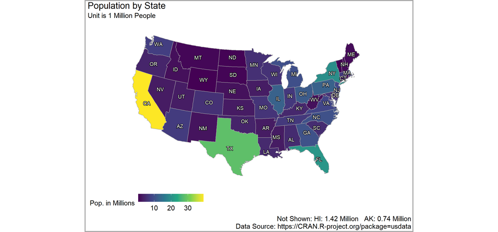

### R Code for US State Pop. Map (with log transformation)

```r
st_lpop <- statepop_map |>
    ggplot(aes(x=long, y=lat, group=group, fill=st_popM)) +
    geom_polygon(color="darkgrey") +
    theme_map() +
    coord_map("albers", lat0 = 39, lat1 = 45) +
    scale_fill_continuous(type = "viridis", trans="log",
                          breaks=c(0,1,2,3,5,10,20,35))  +
    geom_shadowtext(aes(x=m_long, y=m_lat, label=abbr),
                    color="white", check_overlap = T,
                    show.legend = F, size=4) +
    labs(fill= "Pop. in Millions", title="Population by State",
         subtitle="Unit is 1 Million People - Log Transformed",
         caption= "Not Shown: HI: 1.42 Million   AK: 0.74 Million
         Data Source: https://CRAN.R-project.org/package=usdata") +
    theme(legend.position = "bottom",
          legend.key.width = unit(1, "cm"),
          plot.background = element_rect(colour = "darkgrey", fill=NA, size=2),
          plot.title = element_text(size = 20),
          plot.subtitle = element_text(size = 15),
          plot.caption = element_text(size = 15),
          legend.text = element_text(size = 15),
          legend.title = element_text(size = 15))
```

### US State Pop. Map (with log transformation)

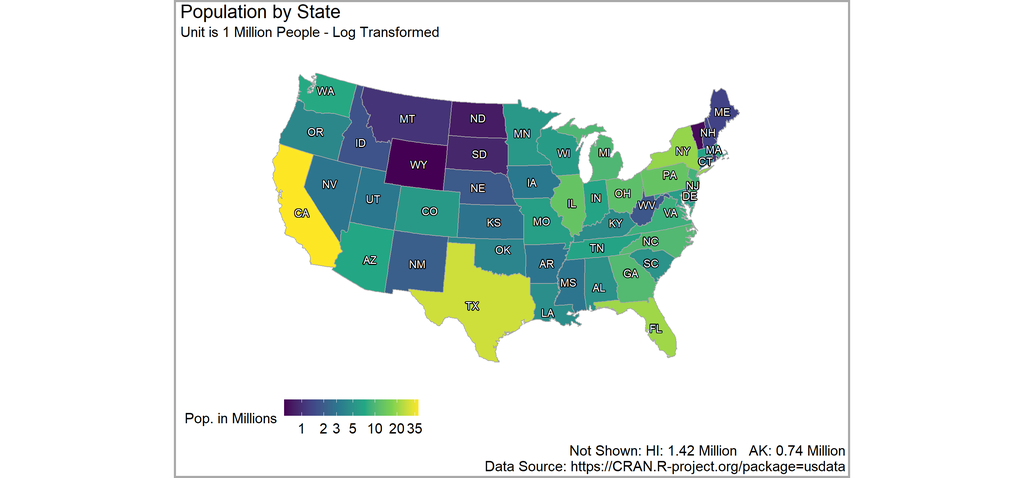

### To log or not to log

In this class, we visualize data using `ggplot`, `hchart`, `dygraph`

If you want to explore but (not present) data, you can also use base graphics for quick plots

- Base graphics could also be used to make polished visualizations but the code is much longer and more tedious than `ggplot`

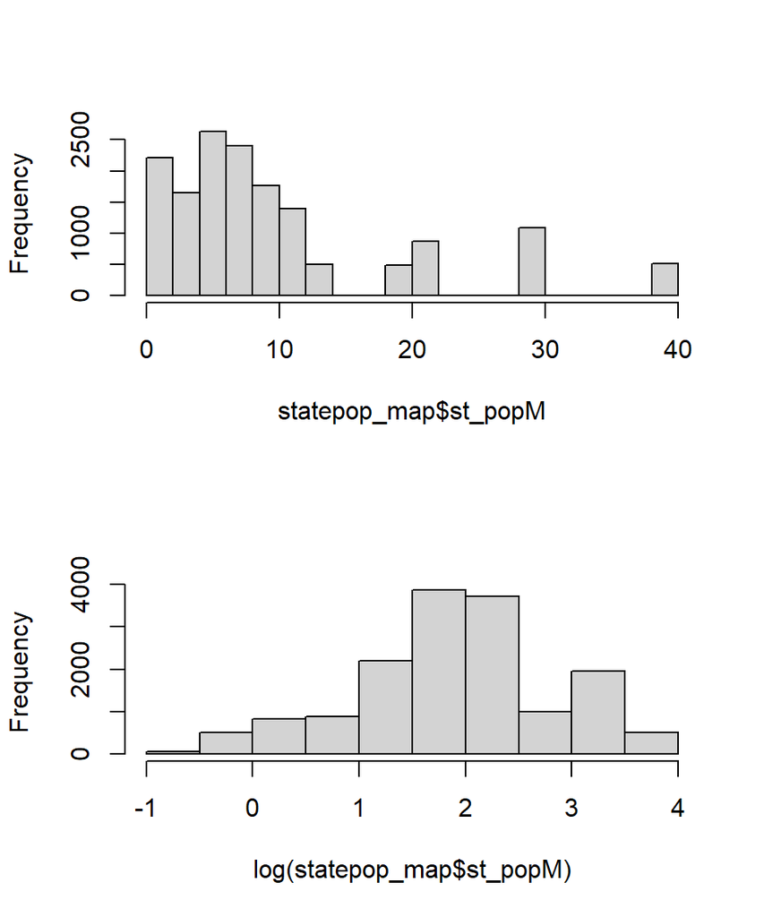

```r
par(mfrow=c(2,1)) # stacks base graph plots
hist(statepop_map$st_popM, main="")
hist(log(statepop_map$st_popM), main="")
```

```r
par(mfrow=c(1,1)) # resets base graph options
```

### Filtering a Map to a Region

- Map techniques above can also be used for a region
- Demo that follows uses an education dataset with data filtered to 10 Northeastern states

```r
edu <- read_csv("education by state.csv", skip=3, show_col_types = F, # import data
                col_names = c("state", "pop_over_25", "pop_hs", "pct_hs",
                              "pop_bachelor", "pct_bachelor",
                              "pop_advanced","pct_advanced"))
edu1 <- edu |>
  select(state, pop_bachelor, pct_bachelor) |>
  mutate(state = str_trim(state) |> tolower(),
         pop_bachelor1K = pop_bachelor/1000,
         pct_bachelor = gsub("%","", pct_bachelor, fixed = T) |> as.numeric()) |>
  filter(state %in% c("maine", "massachusetts", "connecticut" , "rhode island",
                      "vermont", "new hampshire", "new york", "new jersey", "pennsylvania",
                      "delaware")) |> glimpse()
```

```
## Rows: 10
## Columns: 4
## $ state          <chr> "vermont", "rhode island", "pennsylvania", "new york", …
## $ pop_bachelor   <dbl> 172272, 260275, 2917402, 5166218, 2551765, 368237, 2181…
## $ pct_bachelor   <dbl> 38.66, 34.84, 32.31, 37.81, 41.22, 37.58, 44.98, 33.19,…
## $ pop_bachelor1K <dbl> 172.272, 260.275, 2917.402, 5166.218, 2551.765, 368.237…
```

### Exploratory Bachelor Degree Data Plots (Base-R)

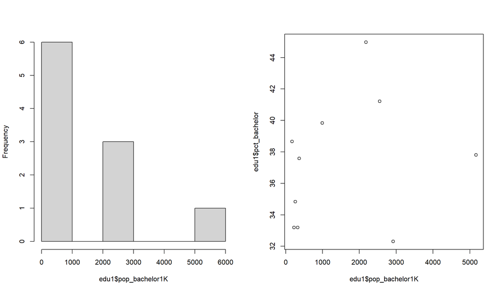

#### Week 12 In-class Exercises

*TurningPoint Session ID: bua455s22*

#### TP Question 1 (L20)

What exploratory plot command (base R code shown) is good for checking if the variable you want to plot is right skewed and might need to be log transformed?

#### TP Question 2 (L20)

Based on the histogram for the northeastern area of the U.S, which includes only 10 states, do these data appear skewed?

### Add Education Data to Map Data

In the chunk below we start from scratch with state data. This chunk does not depend on the data being imported and managed in a previous chunk.

```r
us_states <- map_data("state") |>    # state polygons (from R)
  select(long:region) |> rename("state" = "region")
state_abbr <- state_stats |>         # state abbreviations
  select(state, abbr) |> mutate(state = tolower(state))

edu1 <- left_join(edu1, state_abbr)      # left join to maintain filter to NE states
edu_NE_map <- left_join(edu1, us_states) # left join to maintain filter to NE states
state_coords <- read_csv("state_coords.csv", show_col_types = F,       # add in state midpoints (centroids)
                         col_names = c("state", "m_lat", "m_long")) |>
  mutate(state = gsub(", USA", "", state, fixed=T),
         state = gsub(", the USA", "", state, fixed=T),
         state = gsub(", the US", "", state, fixed=T),
         state = tolower(state))
edu_NE_map <- left_join(edu_NE_map, state_coords)  # left join to maintain filter to NE states
```

### Code for Regional Map 1 - Population with Bachelor’s Degree

[Data Source - Wikipedia](https://en.wikipedia.org/wiki/List_of_U.S._states_and_territories_by_educational_attainment)

```r
ne_edu_pop <- edu_NE_map |>
  ggplot(aes(x=long, y=lat, group=group, fill=pop_bachelor1K)) +   # pop in 1000s
  geom_polygon(color="darkgrey") +
  theme_map() +
  coord_map("albers", lat0 = 39, lat1 = 45) +
  scale_fill_continuous(type = "viridis", trans="log",             # log transformation
                        breaks = c(100, 500, 1000, 5000)) +
  geom_shadowtext(aes(x=m_long, y=m_lat, label=abbr),
                  color="white", check_overlap = T, show.legend = F, size=4) +
  labs(fill= "Unit: 1000 People",
       title="NE States: Pop. with a Bachelor's Degree") +
  theme(legend.position = "bottom",
        legend.key.width = unit(1, "cm"),
        plot.title = element_text(size = 20),
        plot.subtitle = element_text(size = 15),
        plot.caption = element_text(size = 15),
        legend.text = element_text(size = 15),
        legend.title = element_text(size = 15))
```

### Code for Regional Map 2 - Percentage of People with Bachelor’s Degree

[Data Source - Wikipedia](https://en.wikipedia.org/wiki/List_of_U.S._states_and_territories_by_educational_attainment)

```r
ne_edu_pct <- edu_NE_map |>
  ggplot(aes(x=long, y=lat, group=group, fill=pct_bachelor)) +        # percent data
  geom_polygon(color="darkgrey") +
  theme_map() +
  coord_map("albers", lat0 = 39, lat1 = 45) +
  scale_fill_continuous(type = "viridis",                             # no transformation needed
                        breaks = c(32, 34, 36, 38, 40, 42, 44)) +
  geom_shadowtext(aes(x=m_long, y=m_lat, label=abbr),
                  color="white", check_overlap = T, show.legend = F, size=4) +
  labs(fill= "Unit: %", title="NE States: Percent with a Bachelor's Degree") +
  theme(legend.position = "bottom",
        legend.key.width = unit(1, "cm"),
        plot.title = element_text(size = 20),
        plot.subtitle = element_text(size = 15),
        plot.caption = element_text(size = 15),
        legend.text = element_text(size = 15),
        legend.title = element_text(size = 15))
```

### Population and Percentage with Bachelor’s Degrees Side by Side

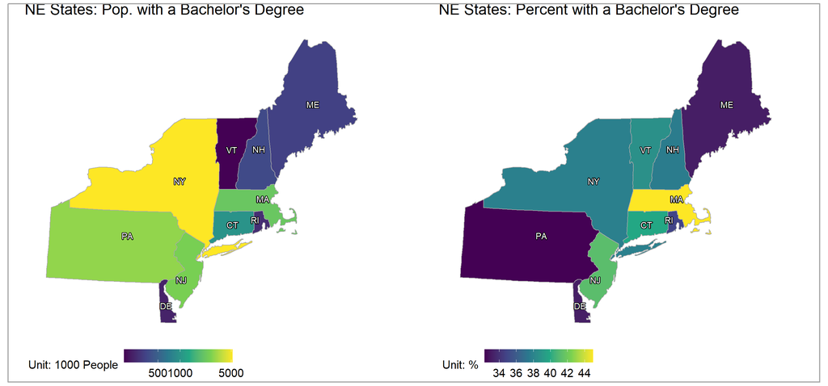

### Managing Projects

- Some of this should be review
- After break, we will talk about managing a long term consulting project
  - Managing files over time
  - Segmenting and rejoining poorly formatted data
  - Documenting steps as you progress
  - Addressing client needs as they eveolve and update requests
- Documentation is key
  - Take good notes and keep README file updated
- I use a Markdown files for everything, even work I don’t present to client.
  - Ideal format for writing notes between code chunks

### What Goes where in a BUA 455 R Projects

#### **code_data_output folder** should have:

- All raw .csv files needed
- *NO data management should be done in Excel.*
- Any .png or other graphics files needed
- Dashboard .rmd file (R Markdown file)
- Dashboard .html file (Dashboard presentation)
- NOTE: As you progress in data management (after this course), code, data, and output may be in separate folders
  - requires specifying folder and file name

### What Goes where in a BUA 455 R Projects

#### **Outer Folder** should have

- **code_data_output** folder (see above)
- Complete and accurate **README.txt** file
- **.Rproj** file that is functional
- Other files can be stored in project **Outer** file if needed.
- If other files are stored in this outer folder they must be catalogued in the README file

### Rpubs Exercise

#### **RPubs** (mentioned earlier in this set of slides)

- If you want to publish your dashboard or any HTML file you create in R, you can do so for free.
- R has a public online repository called **[RPubs](https://rpubs.com/)**.
- **Rpubs** is very useful if you want post an html file online and provide the link to it.
- This is particularly useful if for work like the project dashboards.
- As an in class exercise, I will ask you each to create an account and publish your HW 5 - Part 1 dashboard html file
  - This exercise will be useful because it allows you to see how this publication process works
    - You will see how publishing changes the appearance of your panels and text.
    - Once you post your final dashboard you may want to include it as a link in your resume and/or LinkedIn profile.

### Lecture 24 In-class Exercise

**`1.`** Open your HW 5 - Part 1.Rmd file and knit it to create your dashboard.

- Make sure this file has your name in the header.
- It is okay if you haven’t revised it yet for HW 5 - Part 2
- If you don’t have HW 5 - Part 1 done, you can use your html file from another HW Assignment, e.g. HW 4.

**`2.`** Click the Rpubs icon, create a free account, and publish your html file.

- If RStudio asks to install additional packages to complete the publishing process, click `Yes`.

**`3.`** Submit the link to your published file on Blackboard.

### After Break

#### Additional Topics

- Ask me questions about your project (Others may benefit)
- I have some essential and some optional topics including
  - details and recommendations for writing both project memos.
  - managing a consulting project from beginning to end.
  - formatting complex tables using the `gt` package.
- Time permitting, I will also demonstrate and discuss
  - knitting R Markdown to different formats: word, Powerpoint, etc.
  - Next Generation RStudio publishing using **[Quarto](https://quarto.org/)**
    - files are .qmd instead of .Rmd and rendering appears to be streamlined

### More about Next Week:

#### Review of Skillset Terminology

Now that you are (almost) done with BUA 455 and more so, when you graduate you have a very useful set of skills

- Explaining these skills to others is a challenge
- I will spend a little time talking about how to explain those skills to other people
- Preview: It took me decades to figure out how to talk about what I do.
  - Increased interest in Data Science and Analytics has resulted in better terminology
  - [White Paper from DataCamp provides an excellent blueprint](https://drive.google.com/file/d/1_VoM3D6tPftjZpXCnTL8SKYBlOM_4KjG/view?usp=sharing)

### **Key Points from Week 12**

- **More with Geographic Data**
  - Adding Shadow Text
  - Filtering Map Data and Comparing Variables
- **Project Management**
  - Review of skills covered throughout course
  - Managing data projects this way is beneficial
- **Publishing Work on RPubs**
  - Useful for publishing and linking to work

You may submit an ‘Engagement Question’ about each lecture until midnight on the day of the lecture. **A minimum of four submissions are required during the semester.**